# Trait-matching and Resources Simulation

Ben Weinstein

July 27, 2015

# Simulation

I first create data with constant detection for each hummingbird speices, and the interaction frequency is a function of a species hierarcichal model and corolla similarity * resource availability. There is uneven sampling among species.

### Parameters

$log(\lambda_{i,j,k})<-\alpha_i + \beta_i * abs(Bill_i - Corolla_j) * \beta_2 * Resources_k + \beta_3 * Resources_k * abs(Bill_i - Corolla_j)$

The strength of trait matching increases with available resources $\beta_3 = N(-.5,.001)$

**View simulated strength and form of trait matching**

```r
#function that can be used to test different parameters
sim<-function(gamma1,gamma2,gamma3){
#Number of hummingbird species
h_species=10
plant_species=20
months=24
detection=runif(h_species,0,.5)
phenology=1

#Bill sizes
Bill<-rpois(h_species,10)

#Corolla sizes
Corolla<-rpois(plant_species,15)

#Subtract both and take absolute value
traitmatch<-abs(sapply(Corolla,function(x) x - Bill)/10)

#fill out for each month
traitarray<-array(NA,dim=c(h_species,plant_species,months))
#fill for each month
for (x in 1:months){
  traitarray[,,x]<-traitmatch
}

#simulate some poisson distributed resource counts for each replicate
#this will be same for each species to start with.
resources<-array(NA,dim=c(h_species,plant_species,months))

#fill for each month
for (x in 1:months){
  resources[,,x]<-rpois(1,150)
}

#standardize predictors

resources<-array(data=scale(resources),dim=c(h_species,plant_species,months))
traitarray<-array(data=scale(traitarray),dim=c(h_species,plant_species,months))

#regression slope for trait-matching and resources
#trait match
#gamma=-0.5
intercept<-3
sigma_slope1<- 0.001
sigma_intercept<- 0.001

#resources
#gamma2=0
sigma_slope2<- 0.001

#resources * traitmatch
#gamma3=0
sigma_slope3<- 0.001

#draw values from hierarcichal distributions
beta1<-rnorm(h_species,gamma1,sigma_slope1)
beta2<-rnorm(h_species,gamma2,sigma_slope2)
beta3<-rnorm(h_species,gamma3,sigma_slope3)

alpha<-rnorm(h_species,intercept,sigma_intercept)

#fit regression
lambda<-exp(alpha + beta1 * traitarray + beta2 * resources + beta3 * resources * traitarray)

true_interactions<-array(data=sapply(lambda,function(x){rpois(1,x)}),dim=c(h_species,plant_species,months))

#combine and melt into a single datafFrame
mdat<-dcast(melt(list(y=true_interactions,traitmatch=traitarray,resources=resources)),Var1+Var2+Var3~L1)
return(mdat)}
```

Simulate a variety of patterns to understand the relationship among the variables

1. Species interactions are based solely on trait matching. No effect of resources and no interaction effect.

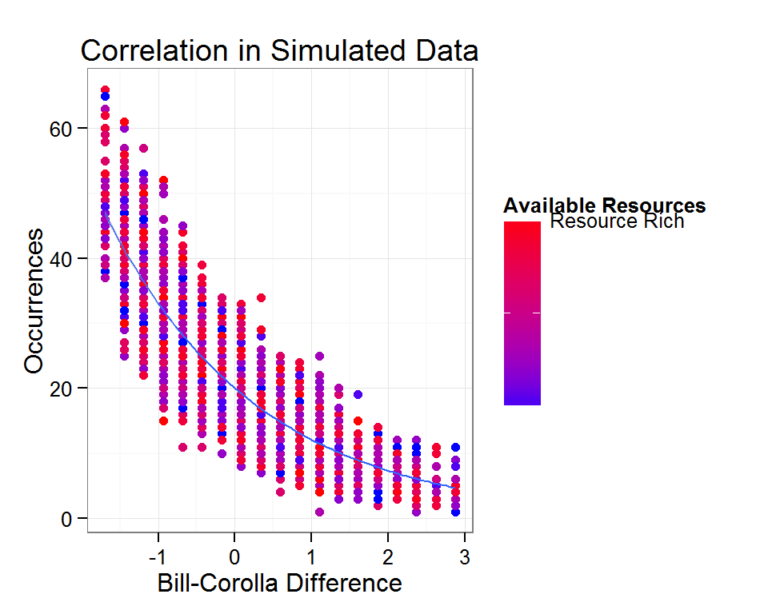

```r
mdat<-sim(-.5,0,0)
ggplot(mdat,aes(col=resources,y=y,x=traitmatch)) + geom_point() + geom_smooth(aes(group=1),method="glm",family="poisson",formula=y~x) + theme_bw() + labs(x="Bill-Corolla Difference",y="Occurrences","Hummingbird") + ggtitle("Correlation in Simulated Data") + labs(col="Available Resources") + scale_color_continuous(low="blue",high="red",breaks=c(-2,0,1.5),labels=c("Resource Poor","","Resource Rich"))
```

2. Species interactions are based on similiarity in morphology and abundance of resources, without an interaction. As resources increase, species interact more with all resources. Red on top, blue on the bottom.

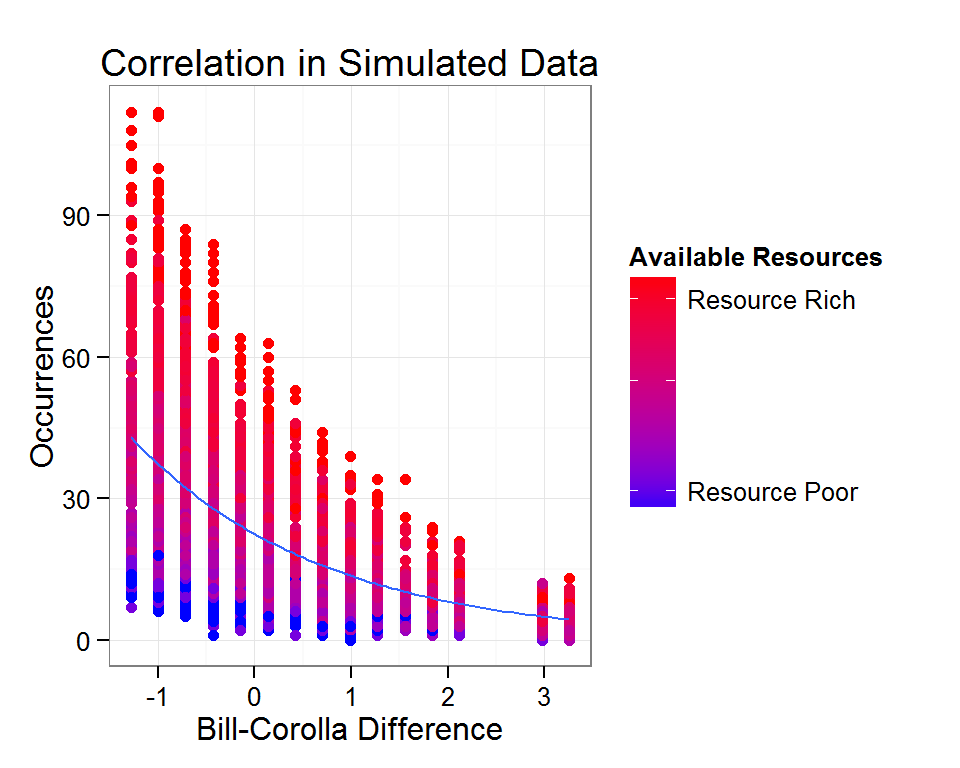

```r
mdat<-sim(-.5,.5,0)
ggplot(mdat,aes(col=resources,y=y,x=traitmatch)) + geom_point() + geom_smooth(aes(group=1),method="glm",family="poisson",formula=y~x) + theme_bw() + labs(x="Bill-Corolla Difference",y="Occurrences","Hummingbird") + ggtitle("Correlation in Simulated Data") + labs(col="Available Resources") + scale_color_continuous(low="blue",high="red",breaks=c(-2,0,1.5),labels=c("Resource Poor","","Resource Rich"))
```

3. Species interactions are based on similiarity in morphology and abundance of resources, without an interaction. As resources decrease, species interact more with all resources. Blue on top, red on the bottom.

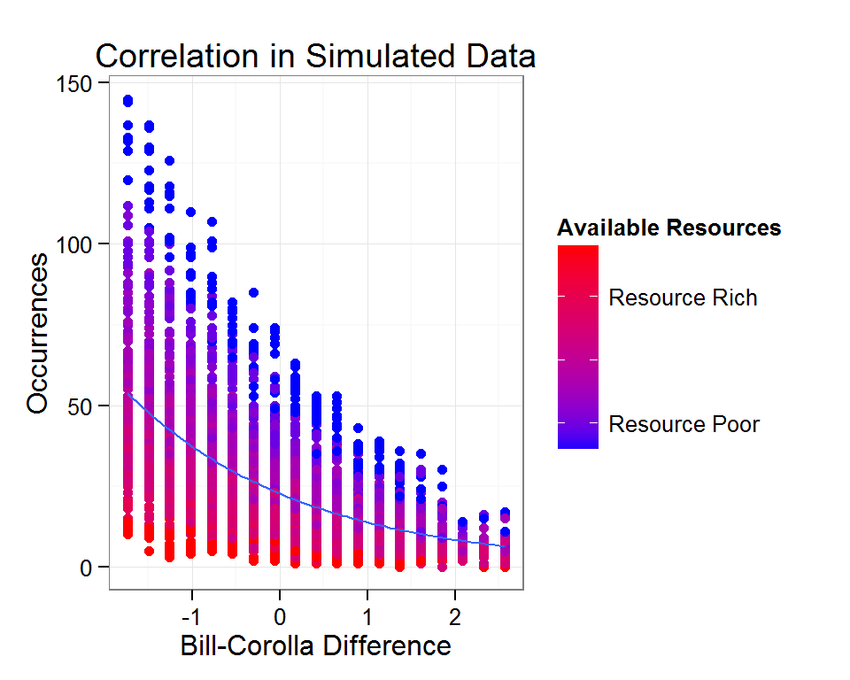

```r
mdat<-sim(-.5,-.5,0)
ggplot(mdat,aes(col=resources,y=y,x=traitmatch)) + geom_point() + geom_smooth(aes(group=1),method="glm",family="poisson",formula=y~x) + theme_bw() + labs(x="Bill-Corolla Difference",y="Occurrences","Hummingbird") + ggtitle("Correlation in Simulated Data") + labs(col="Available Resources") + scale_color_continuous(low="blue",high="red",breaks=c(-1.5,0,1.5),labels=c("Resource Poor","","Resource Rich"))
```

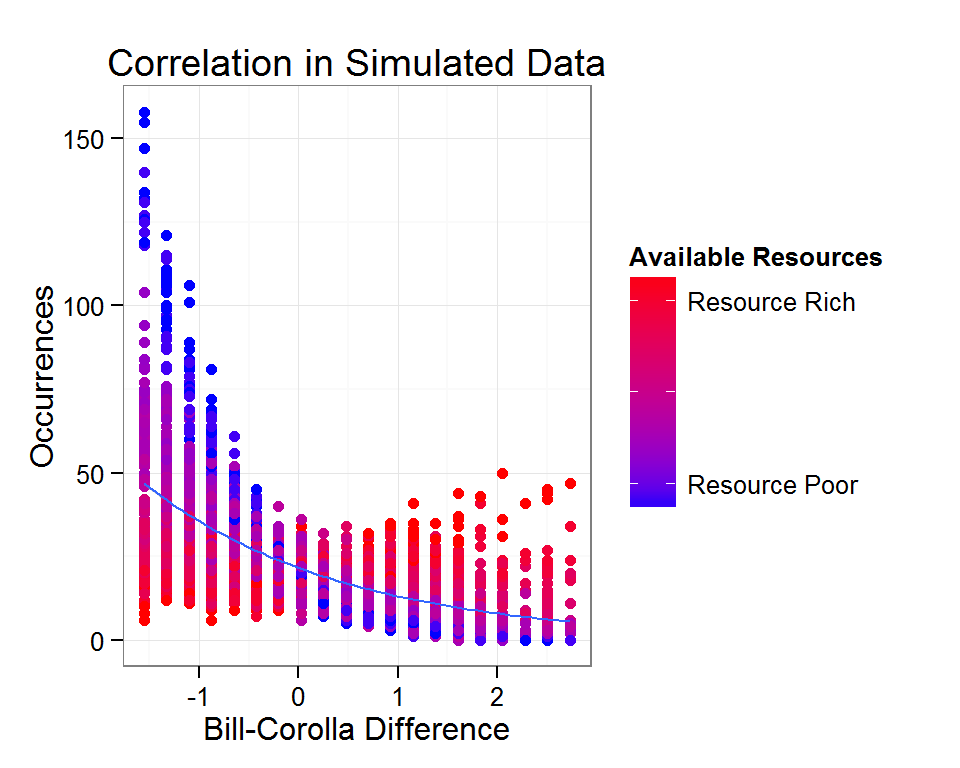

```r
mdat<-sim(-.5,0,.4)
ggplot(mdat,aes(col=resources,y=y,x=traitmatch)) + geom_point() + geom_smooth(aes(group=1),method="glm",family="poisson",formula=y~x) + theme_bw() + labs(x="Bill-Corolla Difference",y="Occurrences","Hummingbird") + ggtitle("Correlation in Simulated Data") + labs(col="Available Resources") + scale_color_continuous(low="blue",high="red",breaks=c(-1.5,0,1.5),labels=c("Resource Poor","","Resource Rich"))
```

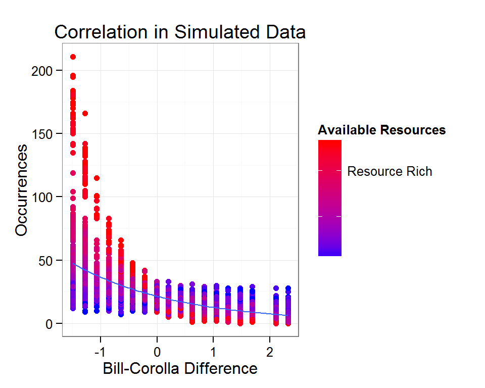

```r
mdat<-sim(-.5,0,-.4)
ggplot(mdat,aes(col=resources,y=y,x=traitmatch)) + geom_point() + geom_smooth(aes(group=1),method="glm",family="poisson",formula=y~x) + theme_bw() + labs(x="Bill-Corolla Difference",y="Occurrences","Hummingbird") + ggtitle("Correlation in Simulated Data") + labs(col="Available Resources") + scale_color_continuous(low="blue",high="red",breaks=c(-1.5,0,1.5),labels=c("Resource Poor","","Resource Rich"))
```

For this manuscript we are most interested in the interaction effect. Let’s look at that estimate for each of the cases we just outlined.

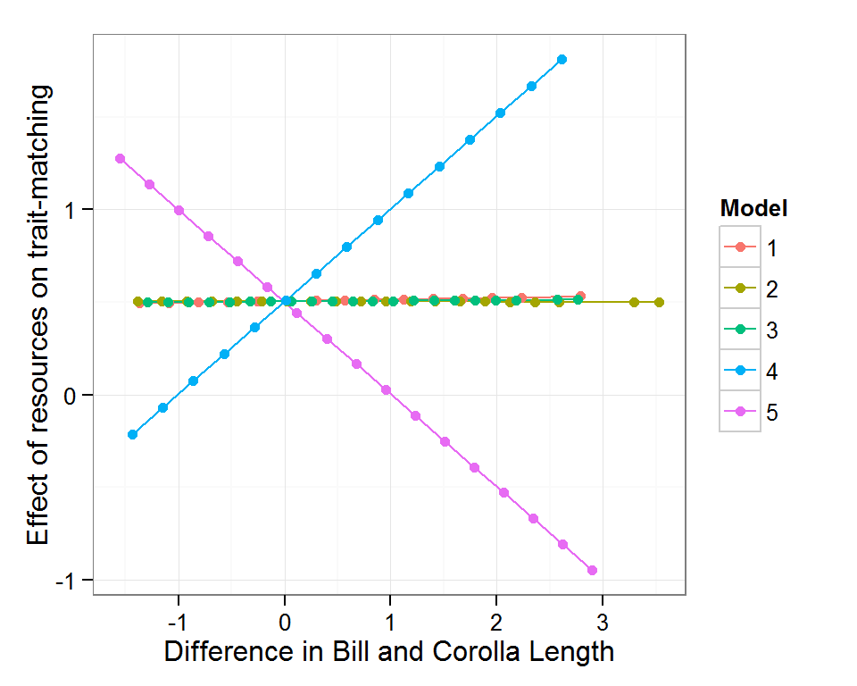

```r
sim1<-sim(.5,0,0)
sim2<-sim(.5,.5,0)
sim3<-sim(.5,-.5,0)
sim4<-sim(.5,.5,.5)
sim5<-sim(.5,.5,-.5)
sims<-list(sim1,sim2,sim3,sim4,sim5)
names(sims)<-as.character(1:5)

s<-melt(sims,id.vars=colnames(sim1))
modlist<-list()
for (x in 1:length(sims)){
mod<-glm(data=sims[[x]],y~resources*traitmatch,family="poisson")
cond<-mod$coefficients[3] + mod$coefficients[4] * mod$data$traitmatch
d<-data.frame(R_effect=cond,traitmatch=mod$data$traitmatch,model=x)
modlist[[x]]<-d
}
modlist<-rbind_all(modlist)
ggplot(modlist,aes(x=traitmatch,y=R_effect,col=as.factor(model))) + geom_line() + labs(col="Model",x="Difference in Bill and Corolla Length",y="Effect of resources on trait-matching") + geom_point() + theme_bw()
```

- Model 1: Increased resources has no effect on trait-matching
- Model 2: Increased resources has no effect on trait-matching
- Model 3: Increased resources has no effect on trait-matching
- Model 4: As there are more available resources, birds choose resources more different from their bill lengths
- Model 5: As there are more available resources, birds choose resources more similiar to their bill lengths

### True Interaction Matrix

```r
#Reshape into a nicer format
colnames(mdat)<-c("Hummingbird","Plant","Month","Bill_Diff","Resources","True_State")

trueplot<-ggplot(mdat,aes(y=as.factor(Plant),x=as.factor(Hummingbird),fill=True_State)) + geom_tile() + labs(x="Hummingbird",y="Plant",fill="Presence") + ggtitle("True State ") + scale_fill_continuous(low="white",high="red","Occurrences")
```

# Simulate Model 5 and add Incomplete Detection

```r
##Simulate detection f
h_species=10
plant_species=20
months=24
detection=runif(h_species,0,1)
phenology=1

#Bill sizes
Bill<-rpois(h_species,10)

#Corolla sizes
Corolla<-rpois(plant_species,15)

#Subtract both and take absolute value
traitmatch<-abs(sapply(Corolla,function(x) x - Bill)/10)

#fill out for each month
traitarray<-array(NA,dim=c(h_species,plant_species,months))
#fill for each month
for (x in 1:months){
  traitarray[,,x]<-traitmatch
}

#simulate some poisson distributed resource counts for each replicate
#this will be same for each species to start with.
resources<-array(NA,dim=c(h_species,plant_species,months))

#fill for each month
for (x in 1:months){
  resources[,,x]<-rpois(1,150)
}

#standardize predictors

resources<-array(data=scale(resources),dim=c(h_species,plant_species,months))
traitarray<-array(data=scale(traitarray),dim=c(h_species,plant_species,months))

#regression slope for trait-matching and resources
#trait match
gamma1=-0.5
intercept<-3
sigma_slope1<- 0.001
sigma_intercept<- 0.001

#resources
gamma2=0
sigma_slope2<- 0.001

#resources * traitmatch
gamma3=-.5
sigma_slope3<- 0.001

#draw values from hierarcichal distributions
beta1<-rnorm(h_species,gamma1,sigma_slope1)
beta2<-rnorm(h_species,gamma2,sigma_slope2)
beta3<-rnorm(h_species,gamma3,sigma_slope3)

alpha<-rnorm(h_species,intercept,sigma_intercept)

#fit regression
lambda<-exp(alpha + beta1 * traitarray + beta2 * resources + beta3 * resources * traitarray)

true_interactions<-array(data=sapply(lambda,function(x){rpois(1,x)}),dim=c(h_species,plant_species,months))

#combine and melt into a single datafFrame
mdat<-dcast(melt(list(y=true_interactions,traitmatch=traitarray,resources=resources)),Var1+Var2+Var3~L1)
```

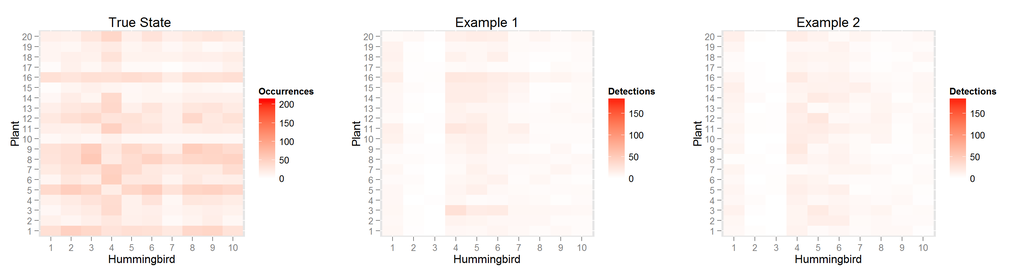

```r
#For each species loop through and create a replicate dataframe
obs<-array(dim=c(h_species,plant_species,months))

#Which months are plants in bloom?
#This is the phenology matrix
sampled<-replicate(plant_species,rbinom(months,1,phenology))
sampled[sampled==0]<-NA

for(x in 1:h_species){
  for (y in 1:plant_species){

    #True State
    ts<-true_interactions[x,y,]

    #detections are function of phenology detection probability and occupancy
    det<-rbinom(months,ts,detection[x])

    #detections and phenology
    obs[x,y,]<-det *sampled[,y]
    }
  }

#plot observed state
obs.state<-melt(obs)
colnames(obs.state)<-c("Hummingbird","Plant","Month","Detections")

#turn NA's to 0
obs.state$Detections[is.na(obs.state$Detections)]<-0

obs.state$Hummingbird<-as.factor(obs.state$Hummingbird)
obs.state$Plant<-factor(obs.state$Plant,levels=1:plant_species)

ob1<-ggplot(obs.state[obs.state$Month==12,],aes(x=Hummingbird,y=Plant,fill=Detections)) + geom_tile() + scale_fill_continuous(low="white",high="Red",limits=c(0,max(mdat$y))) + ylab("Plant") + ggtitle("Example 1") + xlab("Hummingbird")

ob2<-ggplot(obs.state[obs.state$Month==18,],aes(x=Hummingbird,y=Plant,fill=Detections)) + geom_tile() + scale_fill_continuous(low="white",high="Red",limits=c(0,max(mdat$y))) + ylab("Plant") + ggtitle("Example 2") + xlab("Hummingbird")

grid.arrange(trueplot,ob1,ob2,nrow=1)
```

The left hand panel is the true state for each hummingbird plant combination. The middle and right hand panel are two realizations that might result from a month of sampling given incomplete detection and phenology.

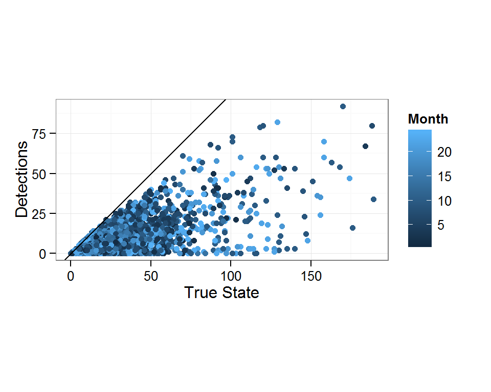

```r
colnames(mdat)<-c("Hummingbird","Plant","Month","resources","traitmatch","y")
d<-merge(mdat,obs.state,by=c("Hummingbird","Plant","Month"))
ggplot(d,aes(x=y,y=Detections,col=Month)) + geom_point() + theme_bw() + geom_abline() + coord_equal() + labs(x="True State")
```

## Hierarcichal Occupancy Model Formulation

$Y_{i,j,k} \sim Binom(N_{i,j},detect_i)$

$N_{i,j} \sim Pois(\lambda_{i,j})$

$log(\lambda_{i,j,k})<-\alpha_i + \beta_i * abs(Bill_i - Corolla_j) * \beta_2 * Resources_k + \beta_3 * Resources_k * abs(Bill_i - Corolla_j)$

$detect_i \sim U(0,1)$

**Priors**

$\alpha_i \sim N(intercept,\tau_{\alpha})$ $\beta_{1,i} \sim N(\gamma_1i,\tau_{\beta_1})$ $\beta_{2,i} \sim N(\gamma_2i,\tau_{\beta_2})$ $\beta_{3,i} \sim N(\gamma_3i,\tau_{\beta_3})$

**Hyperpriors** $gamma_{1,i} \sim N(0.001,0.001)$ $gamma_{2,i} \sim N(0.001,0.001)$ $gamma_{3,i} \sim N(0.001,0.001)$ $intercept \sim N(0.001,0.001)$

$\tau_{\alpha} \sim Intercept (0.001,0.001)$ $\tau_\beta1 \sim \gamma_1i(0.001,0.001)$ $\tau_\beta2 \sim \gamma_2i(0.001,0.001)$ $\tau_\beta3 \sim \gamma_3i(0.001,0.001)$

**Derived quantities**

$\sigma_{int} = \frac{1}{\tau_{\alpha}}^2$ $\sigma_{slope1} = \frac{1}{\tau_{\beta_1}}^2$ $\sigma_{slope2} = \frac{1}{\tau_{\beta_2}}^2$ $\sigma_{slope3} = \frac{1}{\tau_{\beta_3}}^2$

## Hierarcichal Bayesian Model with detection

```r
#Source model
source("NMixtureInteraction.R")

#print model
print.noquote(readLines("NMixtureInteraction.R"))
```

```
##  [1]
##  [2] sink("NMixtureInteraction.jags")
##  [3]
##  [4] cat("
##  [5]     model {
##  [6]     for (i in 1:Birds){
##  [7]       for (j in 1:Plants){
##  [8]         for (k in 1:Months){
##  [9]
## [10]       # True state model for the only partially observed true state
## [11]       log(lambda[i,j,k])<- alpha[i] + beta1[i] * traitmatch[i,j,k] + beta2[i] * resources[i,j,k] + beta3[i] * resources[i,j,k] * traitmatch[i,j,k]
## [12]       N[i,j,k] ~ dpois(lambda[i,j,k])
## [13]
## [14]       # Observation model for the actual observations
## [15]       Y[i,j,k] ~ dbin(detect[i],N[i,j,k])
```

[output cut: 50 more lines]

```r
#Input Data
Dat <- list(
  Y=obs,
  Birds=dim(obs)[1],
  Plants=dim(obs)[2],
  Months=dim(obs)[3],
  resources=resources,
  traitmatch=traitarray)

#A blank Y matrix - all present
initY<-array(dim=c(Dat$Birds,Dat$Plants,Dat$Months),data=max(obs,na.rm=T))

#Inits
InitStage <- function() {list(beta1=rep(.5,Dat$Birds),beta2=rep(.5,Dat$Birds),beta3=rep(.5,Dat$Birds),alpha=rep(.5,Dat$Birds),detect=rep(.5,Dat$Birds),intercept=0,tau_alpha=0.1,tau_beta1=0.1,tau_beta2=0.1,tau_beta3=0.1,N=initY,gamma1=0,gamma2=0,gamma3=0)}

#Parameters to track
ParsStage <- c("detect","alpha","beta1","beta2","beta3","intercept","sigma_int","sigma_slope1","sigma_slope2","sigma_slope3","N","gamma1","gamma2","gamma3","fit","fitnew")

#MCMC options

ni <- 200000  # number of draws from the posterior
nt <- 50  #thinning rate
nb <- ni*.75 # number to discard for burn-in
nc <- 2  # number of chains

#Jags

m = jags(inits=InitStage,
         n.chains=nc,
         model.file="NMixtureInteraction.jags",
         working.directory=getwd(),
         data=Dat,
         parameters.to.save=ParsStage,
         n.thin=nt,
         n.iter=ni,
         n.burnin=nb,
         DIC=T)
```

```
##    Graph Size: 67597
##
```

```r
pars<-extract_par(m)
```

### Assess Convergence

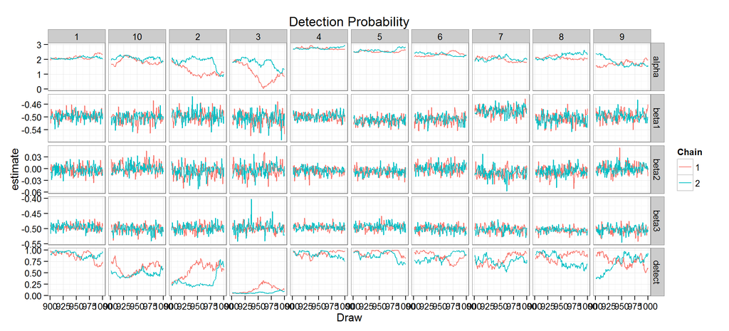

```r
###Chains
ggplot(pars[pars$par %in% c("detect","alpha","beta1","beta2","beta3"),],aes(x=Draw,y=estimate,col=as.factor(Chain))) + geom_line() + facet_grid(par~species,scale="free") + theme_bw() + labs(col="Chain") + ggtitle("Detection Probability")
```

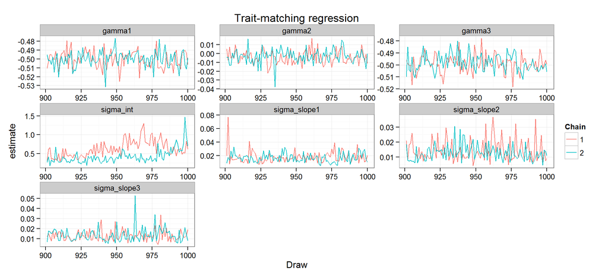

```r
ggplot(pars[pars$par %in% c("gamma1","gamma2","gamma3","sigma_int","sigma_slope1","sigma_slope2","sigma_slope3"),],aes(x=Draw,y=estimate,col=as.factor(Chain))) + geom_line() + theme_bw() + labs(col="Chain") + ggtitle("Trait-matching regression") + facet_wrap(~par,scales="free")
```

### Posteriors

```r
###Posterior Distributions
p<-ggplot(pars[pars$par %in% c("detect","alpha","beta1","beta2","beta3"),],aes(x=estimate)) + geom_histogram() + ggtitle("Estimate of parameters") + facet_grid(species~par,scales="free") + theme_bw() + ggtitle("Species Posteriors")

#Add true values
tr<-melt(data.frame(species=1:length(detection),detect=detection,alpha=alpha,beta1=beta1,beta2=beta2,beta3=beta3),id.var='species')
colnames(tr)<-c("species","par","value")
psim<-p + geom_vline(data=tr,aes(xintercept=value),col='red',linetype='dashed',size=1)
#ggsave("Figures/SimulationPosteriors.jpg",dpi=300,height=8,width=8)
```

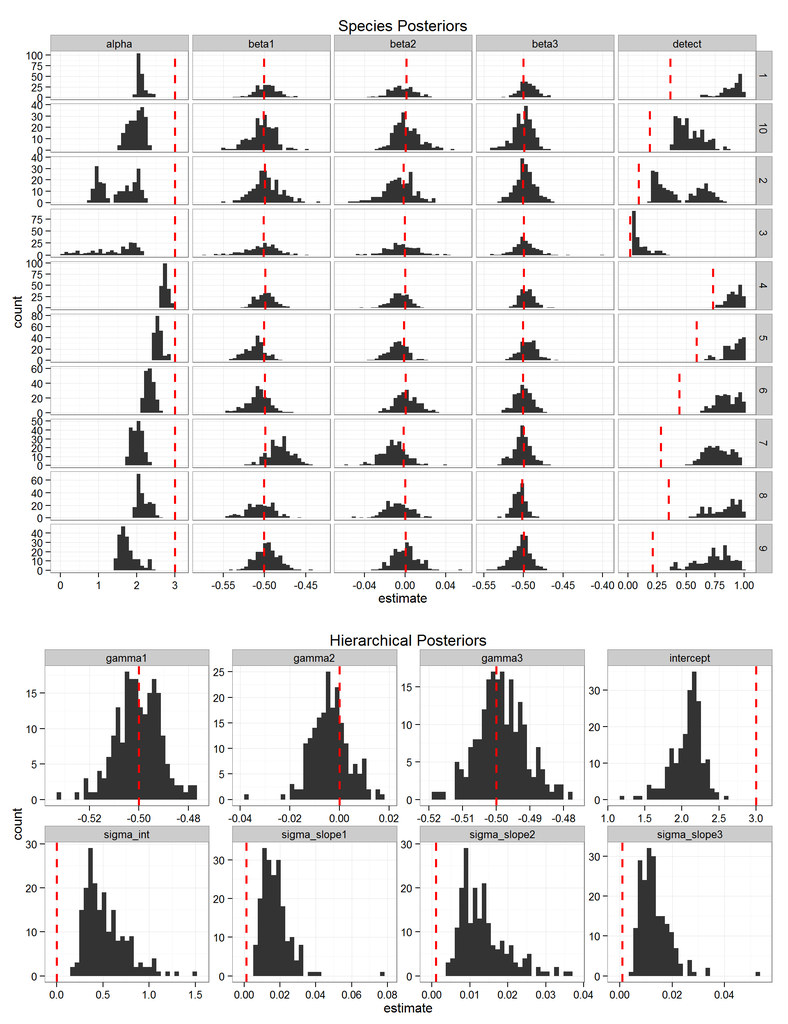

```r
p<-ggplot(pars[pars$par %in% c("gamma1","gamma2","gamma3","intercept","sigma_int","sigma_slope1","sigma_slope2","sigma_slope3"),],aes(x=estimate)) + geom_histogram() + ggtitle("Hierarchical Posteriors") + facet_wrap(~par,scale="free",nrow=2) + theme_bw()

#Add true values
tr<-melt(list(gamma1=gamma1,gamma2=gamma2,gamma3=gamma3,intercept=intercept,sigma_int=sigma_intercept,sigma_slope1=sigma_slope1,sigma_slope2=sigma_slope2,sigma_slope3=sigma_slope3))

colnames(tr)<-c("value","par")

psim2<-p + geom_vline(data=tr,aes(xintercept=value),linetype='dashed',size=1,col="red")
#ggsave("Figures/SimulationH.jpg",dpi=300,height=4,width=10)
grid.arrange(psim,psim2,heights=c(.6,.4))
```

True values are the dashed lines

### Predicted Relationship

```r
castdf<-group_by(pars,Chain) %>% filter(par %in% c("gamma1","gamma2","gamma3","intercept")) %>% select(par,estimate)

castdf<-dcast(pars[pars$par %in% c("gamma1","gamma2","gamma3","intercept"),], Chain + Draw~par,value.var="estimate")

trajF<-function(alpha,beta1,beta2,beta3,x,resources){
  indat<-data.frame(alpha,beta1,beta2,beta3)

  #fit regression for each input estimate
  sampletraj<-list()

  for (y in 1:nrow(indat)){
    v=exp(indat$alpha[y] + indat$beta1[y] * x + indat$beta2[y] * resources + indat$beta3[y] * x*resources)

    sampletraj[[y]]<-data.frame(x=as.numeric(x),y=as.numeric(v))
  }

  sample_all<-rbind_all(sampletraj)

  #Compute CI intervals
  predy<-group_by(sample_all,x) %>% summarise(lower=quantile(y,0.025,na.rm=T),upper=quantile(y,0.975,na.rm=T),mean=mean(y,na.rm=T))
}

#calculate interactions

intF<-function(alpha,beta1,beta2,beta3,x,resources){
  indat<-data.frame(alpha,beta1,beta2,beta3)

  #fit regression for each input estimate
  sampletraj<-list()

  for (y in 1:nrow(indat)){
    v=indat$beta2[y] + indat$beta3[y]  * x
    sampletraj[[y]]<-data.frame(x=as.numeric(x),y=as.numeric(v))
  }

  sample_all<-rbind_all(sampletraj)

  #Compute CI intervals
  predy<-group_by(sample_all,x) %>% summarise(lower=quantile(y,0.025,na.rm=T),upper=quantile(y,0.975,na.rm=T),mean=mean(y,na.rm=T))
}
```

Calculated predicted y

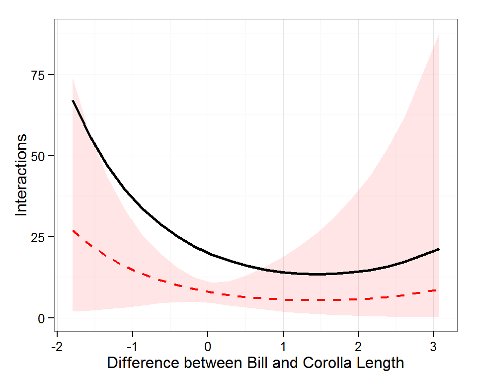

```r
predy<-trajF(alpha=castdf$intercept,beta1=castdf$gamma1,x=as.numeric(traitarray),resources=resources,beta2=castdf$gamma2,beta3=gamma3)

orig<-trajF(alpha=rnorm(2000,intercept,sigma_intercept),beta1=rnorm(2000,gamma1,sigma_slope1),beta2=rnorm(2000,gamma2,sigma_slope2),beta3=rnorm(2000,gamma3,sigma_slope3),x=as.numeric(traitarray),resources=resources)

#plot and compare to original data
psim3<-ggplot(data=predy,aes(x=x)) + geom_ribbon(aes(ymin=lower,ymax=upper),alpha=0.1,fill="red")  + geom_line(aes(y=mean),size=.8,col="red",linetype="dashed") + theme_bw() + ylab("Interactions") + geom_line(data=orig,aes(x=x,y=mean),col='black',size=1)+ xlab("Difference between Bill and Corolla Length")

psim3
```

```r
#ggsave("Figures/SimulationResults.jpg",height=5,width=6,dpi=300)
```

### Visualize interactions

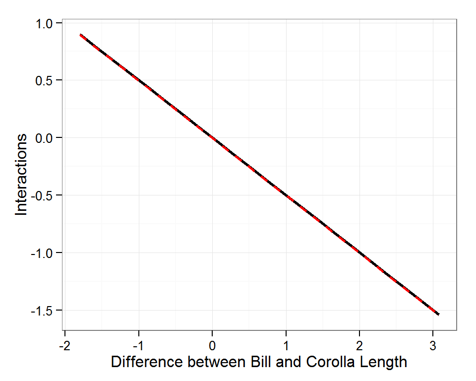

```r
predyint<-intF(alpha=castdf$intercept,beta1=castdf$gamma1,x=as.numeric(traitarray),resources=resources,beta2=castdf$gamma2,beta3=gamma3)

origint<-intF(alpha=rnorm(2000,intercept,sigma_intercept),beta1=rnorm(2000,gamma1,sigma_slope1),beta2=rnorm(2000,gamma2,sigma_slope2),beta3=rnorm(2000,gamma3,sigma_slope3),x=as.numeric(traitarray),resources=resources)

#plot and compare to original data
psim4<-ggplot(data=predyint,aes(x=x)) + geom_ribbon(aes(ymin=lower,ymax=upper),alpha=0.3,fill="red") + theme_bw() + ylab("Interactions") + geom_line(data=origint,aes(x=x,y=mean),col='black',size=1) + geom_line(aes(y=mean),size=.8,col="red",linetype="dashed") + xlab("Difference between Bill and Corolla Length")

psim4
```

### Predicted Frequency

Determining model fit.

```r
#this needs to be fixed, the regular expression doesn't quite match
#any given state
predState<-group_by(pars,par) %>% filter(par=="N") %>% group_by(par,species,plant) %>% summarize(State=as.numeric(names(which.max(table(estimate)))))

predState$species<-as.factor(predState$species)
predState$plant<-factor(predState$plant,levels=1:plant_species)

predplot<-ggplot(predState,aes(x=species,y=plant,fill=State)) + geom_tile() + scale_fill_continuous(na.value="white",low="white",high="red",limits=c(0,max(obs.state$Detection))) + labs(x="Hummingbird",y="Plant",fill="Predicted State") + ggtitle("Predicted") + facet_wrap(~Model)

#compare true and pred states
tr<-melt(true_interactions)
colnames(tr)<-c("Hummingbird","Plant","True_State")

mdat<-merge(predState,tr,by.x=c("species","plant"),by.y=c("Hummingbird","Plant"))

ggplot(mdat,aes(y=State,x=True_State)) + geom_point(size=3) + geom_abline(linetype="dashed") + theme_bw() + xlab("True State") + ylab("Predicted State") + coord_equal()
```

[output not shown]

### Posterior Check

Since I have simualted the data, it should fit as well as any random dataset drawn from the estimated parameters. An ideal fit would be posterior values sitting along the 1:1 line.

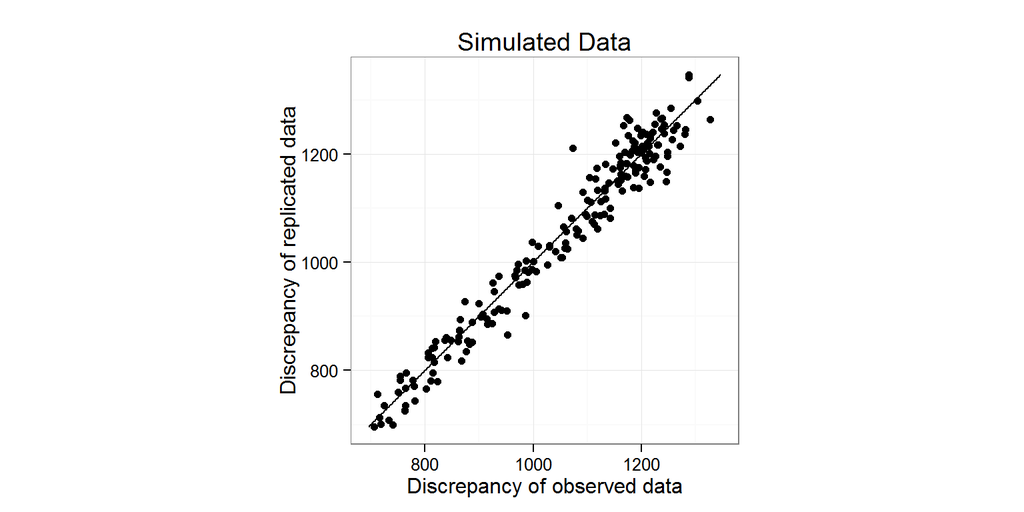

```r
fitstat<-droplevels(pars[pars$par %in% c("fit","fitnew"),])
fitstat<-dcast(fitstat,Draw+Chain~par,value.var="estimate")

#add 1:1 line

ymin<-round(min(c(fitstat$fit,fitstat$fitnew)))
ymax<-round(max(c(fitstat$fit,fitstat$fitnew)))
ab<-data.frame(x=ymin:ymax,y=ymin:ymax)
p<-ggplot(fitstat,aes(x=fit,y=fitnew)) + geom_point() + theme_bw() + coord_equal()
psim5<-p  + labs(x="Discrepancy of observed data",y="Discrepancy of replicated data",col="Model") + geom_line(data=ab,aes(x=x,y=y)) + ggtitle("Simulated Data")

psim5
```

## Detection probabilities

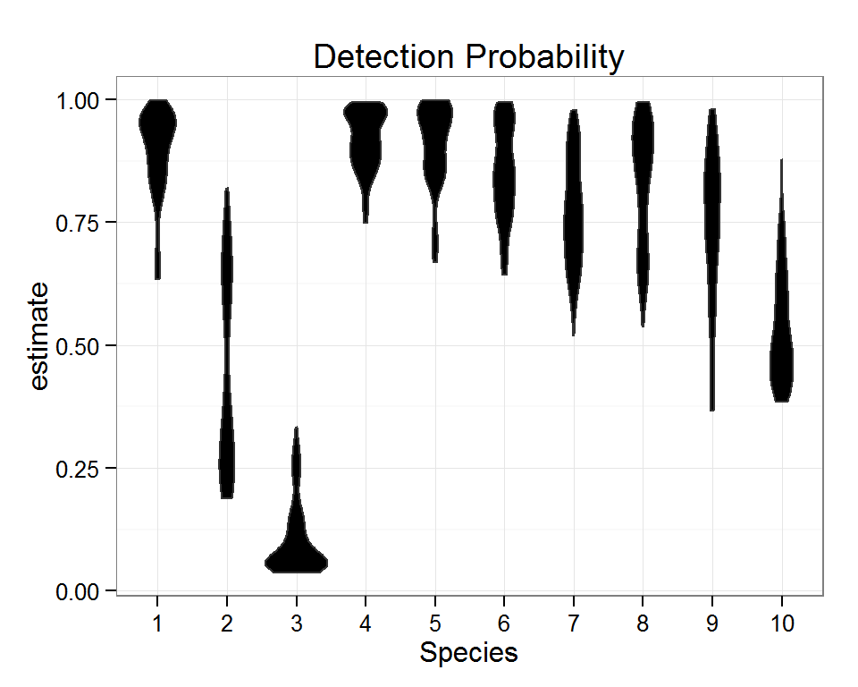

```r
#Detection figure
ggplot(pars[pars$par %in% c("detect"),],aes(x=factor(species,levels=1:max(as.numeric(species))),y=estimate)) + geom_violin(fill='black') + ggtitle("Estimate of parameters") + theme_bw() + ggtitle("Detection Probability") + xlab("Species")
```